# Task#1(Sparks Foundation)

Ali Raza

9/3/2021

## Linear Regression By using R

In this section we will see how the R language can be used to implement regression functions. We will start with simple linear regression involving two variables.

## Simple Linear Regression

In this linear regression task, we are able to expect the proportion of marks that a student is anticipated to score based upon the variety of hours they studied. That is an easy linear regression venture as it involves simply variables.

#### Set Directory for reading the Data sets

To get the current the directory:

```r
getwd()
```

```
## [1] "C:/Users/Ali Raza/Desktop/Sparks Foundation/Task#1"
```

To set the directory where I save the data sets:

```r
setwd("C:/Users/Ali Raza/Desktop/Sparks Foundation/Task#1")
```

## Data Sets

Read the data sets that given for solving the Problem: The given data sets is based on student scores.

```r
s_scores <- read.csv("student_scores - student_scores.csv")
```

#### To Inspect the Data Sets

To View the Upper Row of Given Data Sets

```r
head(s_scores)
```

```
##   Hours Scores
## 1   2.5     21
## 2   5.1     47
## 3   3.2     27
## 4   8.5     75
## 5   3.5     30
## 6   1.5     20
```

To check the detail of Data Sets

```r
summary(s_scores)
```

```
##      Hours           Scores
##  Min.   :1.100   Min.   :17.00
##  1st Qu.:2.700   1st Qu.:30.00
##  Median :4.800   Median :47.00
##  Mean   :5.012   Mean   :51.48
##  3rd Qu.:7.400   3rd Qu.:75.00
##  Max.   :9.200   Max.   :95.00
```

## Loading required R packages For solving the Problem

- Load required packages:
  - ggplot2: for create plot
  - tidyverse for data manipulation and visualization
  - ggpubr: creates easily a publication ready-plot
    - Installed ggrepel for used ggpubr

```r
library(ggplot2)
library(tidyverse)
library(ggpubr)
```

## Visualization

The column names that I used for plotting or visualizing is Hours, Scores

### Scatter plot

Create Scatter plot for the Hours and Scores

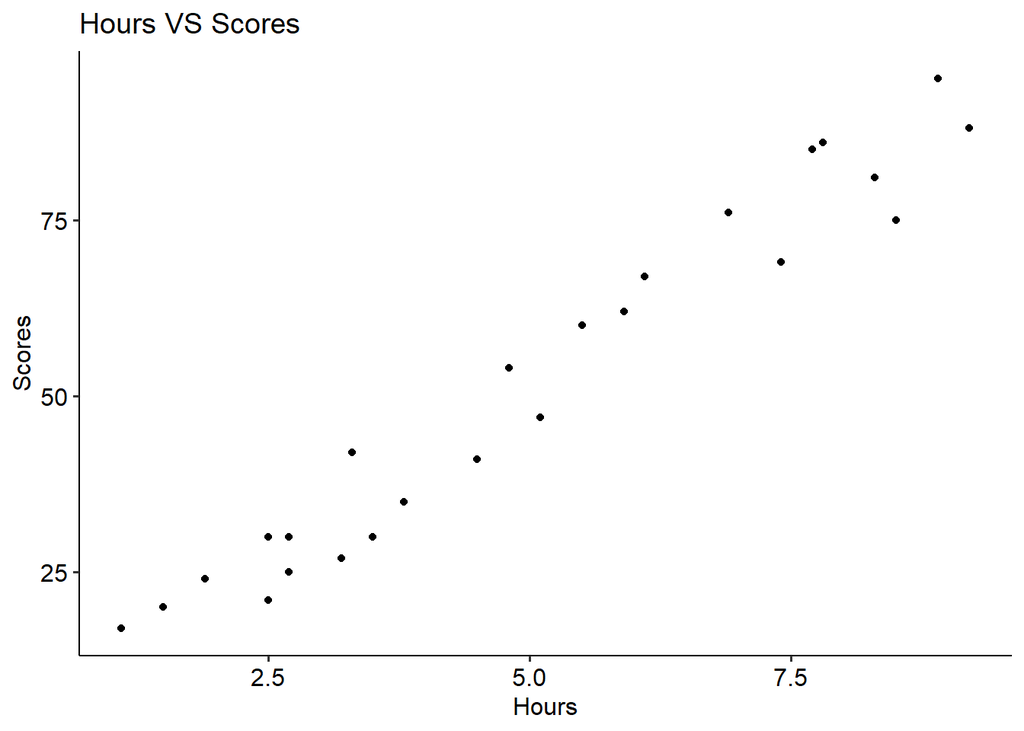

### Scatter Plot with Regression Line

Create Scatter Plot with Regression Line for the Hours and Scores

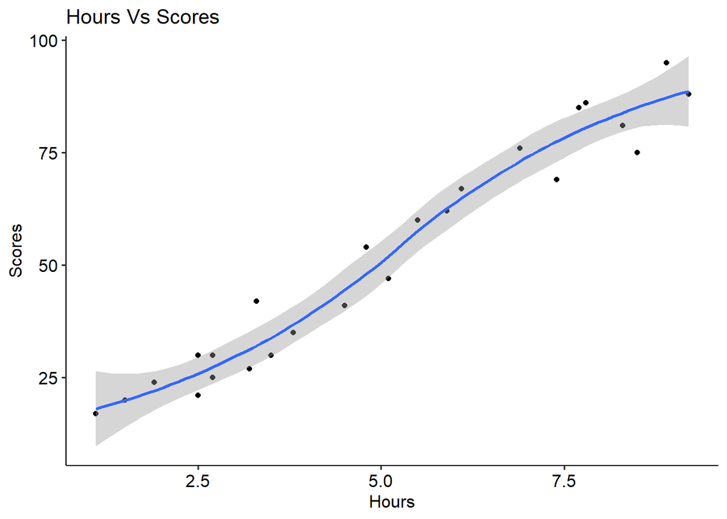

The graph above shows a linearly growing relationship among the Hours and the scores variables. This is a superb factor, because one important assumption of linear regression is that the relationship between the final results and predictor variables is linear and additive.

**So the Graph shows the positive relation.**

### Coorelation

The Correlation coefficient between Hours and Scores of Students.

```r
cor(s_scores$Scores, s_scores$Hours)
```

```
## [1] 0.9761907
```

The correlation coefficient measures the level of the association between two variables x and y.

Its value ranges between -1 (perfect negative correlation: when x increases, y decreases) and +1 (perfect positive correlation: when x increases, y increases).

A value closer to 0 suggests a weak relationship between the variables. A low correlation (-0.2 < x < 0.2) probably suggests that much of variation of the outcome variable (y) is not explained by the predictor (x). In such case, we should probably look for better predictor variables.

**In our Task, the correlation coefficient is large enough, so we can continue by building a linear model of y as a function of x.**

## Linear Regression Model

The simple linear regression tries to find the best line to predict Scores on the basis of Hours.

The linear model equation can be written as follow: **Scores = b0 + b1 x Hours**

The R function **lm()** can be used to determine the beta coefficients of the linear model:

```r
linear_model <- lm(Scores~Hours, data = s_scores)
linear_model
```

```
##
## Call:
## lm(formula = Scores ~ Hours, data = s_scores)
##
## Coefficients:
## (Intercept)        Hours
##       2.484        9.776
```

The Result tell us about the **intercept** and **beta coefficient** of the **Hours**.

### Plotting

Display the Scatter Plot with Simple Linear Regression Line.

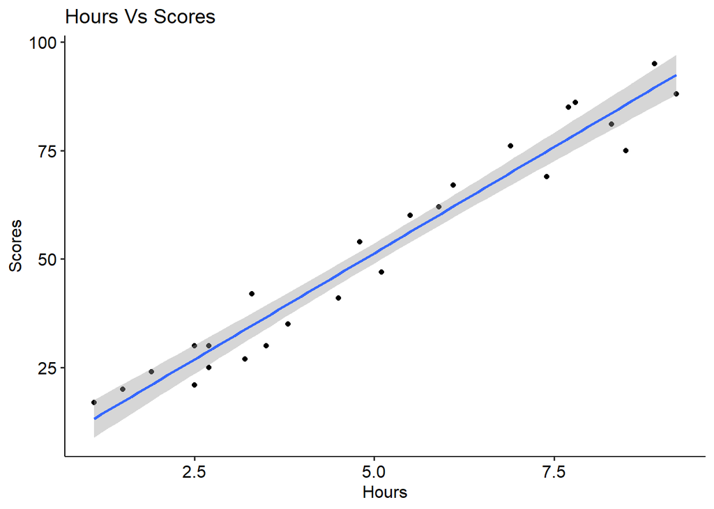

### Summary of Model

I displaying the statistical summary of the model.

```r
summary(linear_model)
```

```
##
## Call:
## lm(formula = Scores ~ Hours, data = s_scores)
##
## Residuals:
##     Min      1Q  Median      3Q     Max
## -10.578  -5.340   1.839   4.593   7.265
##
## Coefficients:
##             Estimate Std. Error t value Pr(>|t|)
## (Intercept)   2.4837     2.5317   0.981    0.337
## Hours         9.7758     0.4529  21.583   <2e-16 ***
## ---
## Signif. codes:  0 '***' 0.001 '**' 0.01 '*' 0.05 '.' 0.1 ' ' 1
##
## Residual standard error: 5.603 on 23 degrees of freedom
## Multiple R-squared:  0.9529, Adjusted R-squared:  0.9509
## F-statistic: 465.8 on 1 and 23 DF,  p-value: < 2.2e-16
```

The summary outputs shows 6 components, including: * **Call**. Shows the function call used to compute the regression model. * **Residuals**. Provide a quick view of the distribution of the residuals, which by definition have a mean zero. Therefore, the median should not be far from zero, and the minimum and maximum should be roughly equal in absolute value * **Coefficients**. Shows the regression beta coefficients and their statistical significance. Predictor variables, that are significantly associated to the outcome variable, are marked by stars. * **Residual standard error (RSE)**, **R-squared (R2)** and the **F-statistic** are metrics that are used to check how well the model fits to our data.

### Coefficients significance

```r
confint(linear_model)
```

```
##                 2.5 %    97.5 %
## (Intercept) -2.753470  7.720817
## Hours        8.838823 10.712784
```

### Check the Model

For check the model accuracy, I measure the percentage in predicting.

```r
sigma(linear_model)*100/mean(s_scores$Scores)
```

```
## [1] 10.88395
```

**So the error percentage is 10.8839534**

## Make Prediction

Predict the score on 9.25 hours, according to given problems or task.

```r
predict(linear_model, data.frame(Hours = 9.25))
```

```
##        1
## 92.90985
```